# Teste de modelos de classificação para satisfação de usuários

##### **Lucas Marra e Thais D. M. Ferreira**

### **Introdução:**

Como parte do exercício de análise do banco do dados de pesquisa de telefonia móvel, serão testados **4 modelos de classificação** com o objetivo de selecionar o modelo com **melhor desempenho preditivo** para a satisfação dos usuários (alta ou baixa). A Base de dados foi tratada e analisada anteriormente em **Python**. Os modelos selecionados foram:

1. **Logística**;
2. **Random Forest**;
3. **Boosting**;
4. **LASSO**

#### **Importação de bibliotecas:**

```r
library(readxl)
library(tidyverse)
library(GGally)
library(skimr)
library(pROC)
library(glmnet)
library(plotmo)
library(skimr)
library(leaps)
library(randomForest)
library(MASS)
library(openxlsx)
library(readxl)
library(xgboost)
library(gbm)
```

#### **Leitura da base de dados**

O primeiro passo é importar a base de dados tratada via Python, arquivo que foi gerado com o nome de BD_Pre_Tratado através do código abaixo.

```r
dados_raw<- read_excel("data/BD_Pre_Tratado.xlsx")
dados_raw <- na.omit(dados_raw)
```

```r
head(dados_raw)
```

| OPERADORA | ESTADO | ANO_BASE | Q5 | Q8 | Q8a | Q9 | J1 | B1_1 | B1_2 | C1_1 | C1_2 | D1 | D2_1 | D2_2 | D2_3 | E1_1 | E1_2 | E1_3 | A1_1 | A1_2 | A1_3 | A1_4 | A2_1 | A2_2 | A2_3 | A3 | A4 | A5 | F1 | … |
| --- | --- | --- | --- | --- | --- | --- | --- | --- | --- | --- | --- | --- | --- | --- | --- | --- | --- | --- | --- | --- | --- | --- | --- | --- | --- | --- | --- | --- | --- | --- |
| OI | RN | 2019 | 1 | 56 | 8 | 1 | 0 | 10 | 7 | 8 | 10 | 2 | 6.957055 | 6.938650 | 6.865031 | 0 | 0 | 10 | 0 | 0 | 1 | 0 | 7.588235 | 7.647059 | 8.411765 | 8.058824 | 8.588235 | 10.000000 | 1 | … |
| CLARO | RN | 2019 | 1 | 56 | 8 | 1 | 10 | 10 | 10 | 10 | 10 | 1 | 10.000000 | 10.000000 | 10.000000 | 10 | 10 | 10 | 1 | 0 | 1 | 0 | 0.000000 | 10.000000 | 10.000000 | 10.000000 | 8.875000 | 10.000000 | 1 | … |
| TIM | SE | 2019 | 1 | 40 | 6 | 2 | 4 | 4 | 5 | 7 | 7 | 2 | 7.221519 | 7.310127 | 7.348101 | 7 | 5 | 8 | 0 | 0 | 0 | 1 | 7.375000 | 7.250000 | 7.000000 | 7.500000 | 7.375000 | 7.500000 | 2 | … |
| OI | GO | 2019 | 1 | 23 | 3 | 1 | 9 | 8 | 7 | 10 | 8 | 1 | 9.000000 | 9.000000 | 9.000000 | 9 | 8 | 9 | 0 | 1 | 0 | 0 | 8.000000 | 9.000000 | 9.166667 | 8.833333 | 8.000000 | 7.833333 | 2 | … |
| TIM | TO | 2019 | 1 | 21 | 3 | 1 | 6 | 7 | 7 | 5 | 6 | 2 | 7.368421 | 7.379501 | 7.739612 | 1 | 3 | 10 | 1 | 0 | 0 | 0 | 8.000000 | 6.000000 | 9.000000 | 6.000000 | 8.157895 | 7.947368 | 1 | … |
| CLARO | MT | 2019 | 1 | 49 | 7 | 2 | 7 | 10 | 10 | 7 | 7 | 2 | 7.672065 | 7.603239 | 7.566802 | 10 | 10 | 10 | 0 | 0 | 0 | 1 | 7.055556 | 7.277778 | 6.888889 | 7.500000 | 7.944444 | 8.500000 | 2 | … |

Agora, com a base de dados inserida, podemos iniciar as etapas de modelagem.

Para as notas de satisfação com valores maiores/iguais a 8, a classificação de satisfacao é “Alta”, do contrario serao classificada como “Baixa”. Para atendermos esta condição, foi utilizado o codigo abaixo como forma de classificar tais notas, representadas pela variável **J1** da base de dados.

```r
dados <- dados_raw %>%
  mutate(J1 = factor(ifelse(J1 >= 8, "Alta", "Baixa"),
                          levels = c("Baixa", "Alta")))

head(dados)
```

| OPERADORA | ESTADO | ANO_BASE | Q5 | Q8 | Q8a | Q9 | J1 | B1_1 | B1_2 | C1_1 | C1_2 | D1 | D2_1 | D2_2 | D2_3 | E1_1 | E1_2 | E1_3 | A1_1 | A1_2 | A1_3 | A1_4 | A2_1 | A2_2 | A2_3 | A3 | A4 | A5 | F1 | … |
| --- | --- | --- | --- | --- | --- | --- | --- | --- | --- | --- | --- | --- | --- | --- | --- | --- | --- | --- | --- | --- | --- | --- | --- | --- | --- | --- | --- | --- | --- | --- |
| OI | RN | 2019 | 1 | 56 | 8 | 1 | Baixa | 10 | 7 | 8 | 10 | 2 | 6.957055 | 6.938650 | 6.865031 | 0 | 0 | 10 | 0 | 0 | 1 | 0 | 7.588235 | 7.647059 | 8.411765 | 8.058824 | 8.588235 | 10.000000 | 1 | … |
| CLARO | RN | 2019 | 1 | 56 | 8 | 1 | Alta | 10 | 10 | 10 | 10 | 1 | 10.000000 | 10.000000 | 10.000000 | 10 | 10 | 10 | 1 | 0 | 1 | 0 | 0.000000 | 10.000000 | 10.000000 | 10.000000 | 8.875000 | 10.000000 | 1 | … |
| TIM | SE | 2019 | 1 | 40 | 6 | 2 | Baixa | 4 | 5 | 7 | 7 | 2 | 7.221519 | 7.310127 | 7.348101 | 7 | 5 | 8 | 0 | 0 | 0 | 1 | 7.375000 | 7.250000 | 7.000000 | 7.500000 | 7.375000 | 7.500000 | 2 | … |
| OI | GO | 2019 | 1 | 23 | 3 | 1 | Alta | 8 | 7 | 10 | 8 | 1 | 9.000000 | 9.000000 | 9.000000 | 9 | 8 | 9 | 0 | 1 | 0 | 0 | 8.000000 | 9.000000 | 9.166667 | 8.833333 | 8.000000 | 7.833333 | 2 | … |
| TIM | TO | 2019 | 1 | 21 | 3 | 1 | Baixa | 7 | 7 | 5 | 6 | 2 | 7.368421 | 7.379501 | 7.739612 | 1 | 3 | 10 | 1 | 0 | 0 | 0 | 8.000000 | 6.000000 | 9.000000 | 6.000000 | 8.157895 | 7.947368 | 1 | … |
| CLARO | MT | 2019 | 1 | 49 | 7 | 2 | Baixa | 10 | 10 | 7 | 7 | 2 | 7.672065 | 7.603239 | 7.566802 | 10 | 10 | 10 | 0 | 0 | 0 | 1 | 7.055556 | 7.277778 | 6.888889 | 7.500000 | 7.944444 | 8.500000 | 2 | … |

Para fins de conhecimento de quantas classificações temos como “Alta” e “Baixa”, imprimimos a quantidade de observações contidas na variável J1, conforme abaixo:

```r
table(dados$J1)
```

```
##
## Baixa  Alta
## 69058 72451
```

### **Modelagem preditiva via regressoes Logistica, Random Forest, Boosting e LASSO**.

A seguir, veremos o passo a passo dos codigos utilizados e os resultados obtidos para cada uma das regressoes,

### **1) Regressao Logistica**

No código abaixo geramos a base de treino e teste a partir do dataframe, e em seguida ajustamos a regressão Logistica, representada por `fit_logistica_TT`.

```r
dados_Log <- dados


set.seed(1)

treino_Log <- sample(nrow(dados_Log), .8*nrow(dados_Log), replace =  FALSE)

dados_treino_Log <- dados_Log[treino_Log,]
dados_teste_Log <- dados_Log[-treino_Log,]

#Ajustando pela regressÃ£o logistica
fit_logisticaTT <- glm(J1 ~ ., family = "binomial", data = dados_treino_Log)
```

A seguir, rodamos as probabilidades do modelo para gerarmos uma base de dados com os resultados observados e os estimados.

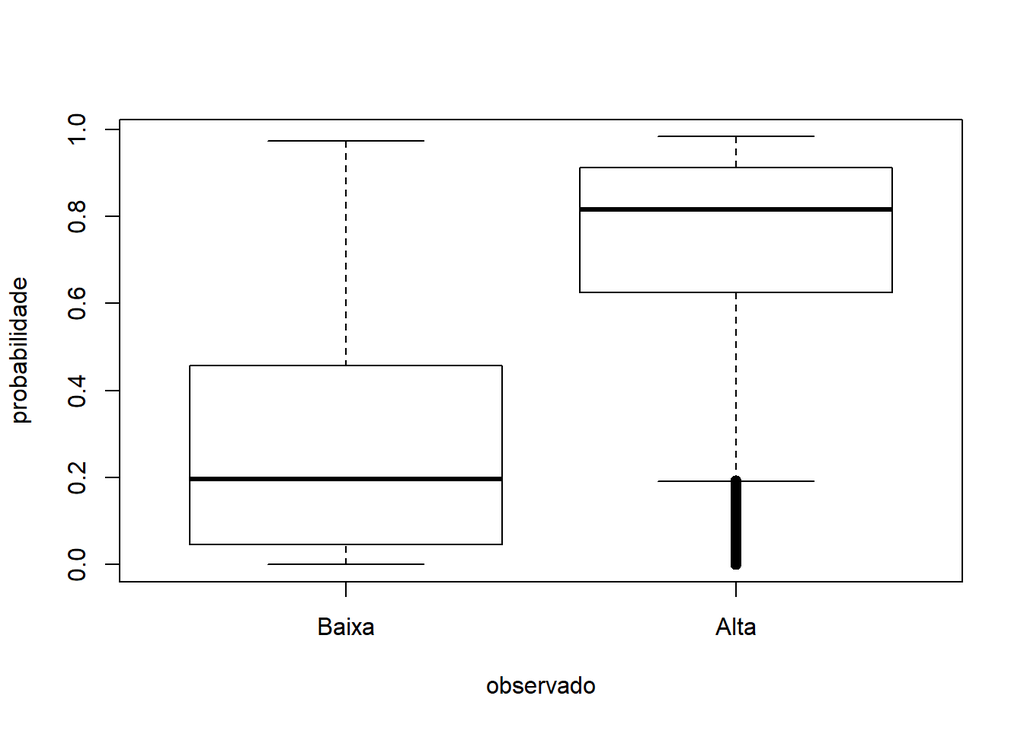

```r
#Obtendo probabilidades
prob_fit_logistica_TT <- predict(fit_logisticaTT, dados_teste_Log, type = "response")

#head(prob_fit_logistica_TT)


#criando base de dados com os resultados observado e as probs
estimativas_fit_logistica_TT <- tibble(observado = dados_teste_Log$J1, probabilidade = prob_fit_logistica_TT)

plot(estimativas_fit_logistica_TT)
```

Agora, após rodar a regressão e as previsões para o modelo, realizaremos a comparação com os resultados observados e os estimados, utilizando a função `roc`, a qual utilizamos para calcular a AUC (area under the curve), para identificar o % de acertos do modelo de previsão.

Abaixo, o calculo da curva ROC, representado pela variável `roc_fit logistica _TT`:

```r
# Curva ROC
roc_fit_logistica_TT <- estimativas_fit_logistica_TT %>%
                    roc(observado, probabilidade)
```

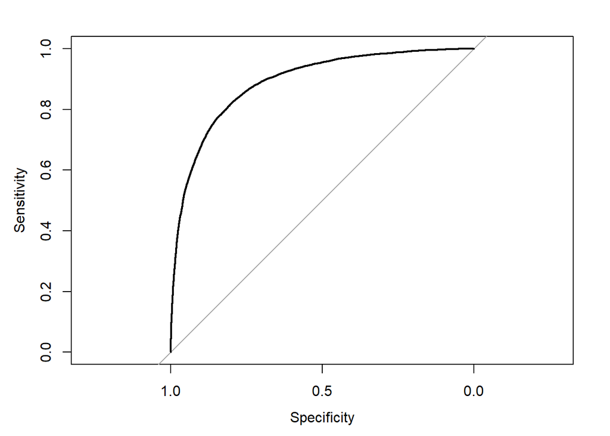

```r
#Rodando curva ROC, obtendo resultado de AUC = 0,8888

plot(roc_fit_logistica_TT)
```

```r
roc_fit_logistica_TT
```

```
##
## Call:
## roc.data.frame(data = ., response = observado, predictor = probabilidade)
##
## Data: probabilidade in 13786 controls (observado Baixa) < 14516 cases (observado Alta).
## Area under the curve: 0.8888
```

Quando imprimimos `roc_fit_logistica_TT` obtivemos uma AUC de 0,8888, ou seja, o modelo tem em media **88,88% de acertos** em suas previsoes.

### **2) Random Forest**

Antes de iniciar a Random Forest, é necessário transformar as variáveis string para factor:

```r
dados_rf <- dados


### Transformando variaveis chr em fct
dados_rf$OPERADORA <- as.factor(dados_rf$OPERADORA)
dados_rf$ESTADO <- as.factor(dados_rf$ESTADO)

head(dados_rf)
```

| OPERADORA | ESTADO | ANO_BASE | Q5 | Q8 | Q8a | Q9 | J1 | B1_1 | B1_2 | C1_1 | C1_2 | D1 | D2_1 | D2_2 | D2_3 | E1_1 | E1_2 | E1_3 | A1_1 | A1_2 | A1_3 | A1_4 | A2_1 | A2_2 | A2_3 | A3 | A4 | A5 | F1 | … |
| --- | --- | --- | --- | --- | --- | --- | --- | --- | --- | --- | --- | --- | --- | --- | --- | --- | --- | --- | --- | --- | --- | --- | --- | --- | --- | --- | --- | --- | --- | --- |
| OI | RN | 2019 | 1 | 56 | 8 | 1 | Baixa | 10 | 7 | 8 | 10 | 2 | 6.957055 | 6.938650 | 6.865031 | 0 | 0 | 10 | 0 | 0 | 1 | 0 | 7.588235 | 7.647059 | 8.411765 | 8.058824 | 8.588235 | 10.000000 | 1 | … |
| CLARO | RN | 2019 | 1 | 56 | 8 | 1 | Alta | 10 | 10 | 10 | 10 | 1 | 10.000000 | 10.000000 | 10.000000 | 10 | 10 | 10 | 1 | 0 | 1 | 0 | 0.000000 | 10.000000 | 10.000000 | 10.000000 | 8.875000 | 10.000000 | 1 | … |
| TIM | SE | 2019 | 1 | 40 | 6 | 2 | Baixa | 4 | 5 | 7 | 7 | 2 | 7.221519 | 7.310127 | 7.348101 | 7 | 5 | 8 | 0 | 0 | 0 | 1 | 7.375000 | 7.250000 | 7.000000 | 7.500000 | 7.375000 | 7.500000 | 2 | … |
| OI | GO | 2019 | 1 | 23 | 3 | 1 | Alta | 8 | 7 | 10 | 8 | 1 | 9.000000 | 9.000000 | 9.000000 | 9 | 8 | 9 | 0 | 1 | 0 | 0 | 8.000000 | 9.000000 | 9.166667 | 8.833333 | 8.000000 | 7.833333 | 2 | … |
| TIM | TO | 2019 | 1 | 21 | 3 | 1 | Baixa | 7 | 7 | 5 | 6 | 2 | 7.368421 | 7.379501 | 7.739612 | 1 | 3 | 10 | 1 | 0 | 0 | 0 | 8.000000 | 6.000000 | 9.000000 | 6.000000 | 8.157895 | 7.947368 | 1 | … |
| CLARO | MT | 2019 | 1 | 49 | 7 | 2 | Baixa | 10 | 10 | 7 | 7 | 2 | 7.672065 | 7.603239 | 7.566802 | 10 | 10 | 10 | 0 | 0 | 0 | 1 | 7.055556 | 7.277778 | 6.888889 | 7.500000 | 7.944444 | 8.500000 | 2 | … |

Com o código abaixo vamos rodar a regressão Random Forest:

```r
set.seed(1)
linhas_rf <- sample(1:nrow(dados_rf), .3*nrow(dados_rf))

### funcao para regressao Random forest
rf <- randomForest(J1 ~ ., data = dados_rf[linhas_rf,])
```

Abaixo, um exemplo de como a construção de uma determinada quantidade de árvores tende a reduzir o erro e, conforme seu numero vai aumentando, temos uma estabilização do OOB.

Para este caso, observamos que este numero se torna praticamente estável a partir de aproximadamente 300 árvores.

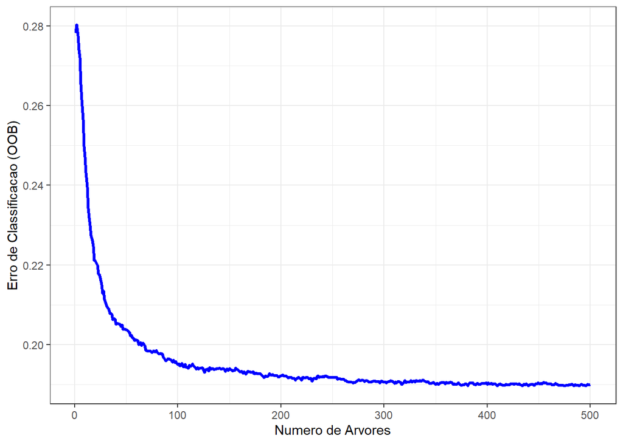

```r
### Construcao de dataframe e plot com erro de classficacao para cada uma das 500 arvores
tibble(arvore = 1:nrow(rf$err.rate),
       oob = rf$err.rate[,1]) %>%
  ggplot(aes(arvore, oob)) +
  geom_line(color = "blue", size = 1.2) +
  ylab("Erro de Classificacao (OOB)") +
  xlab("Numero de Arvores") + theme_bw()
```

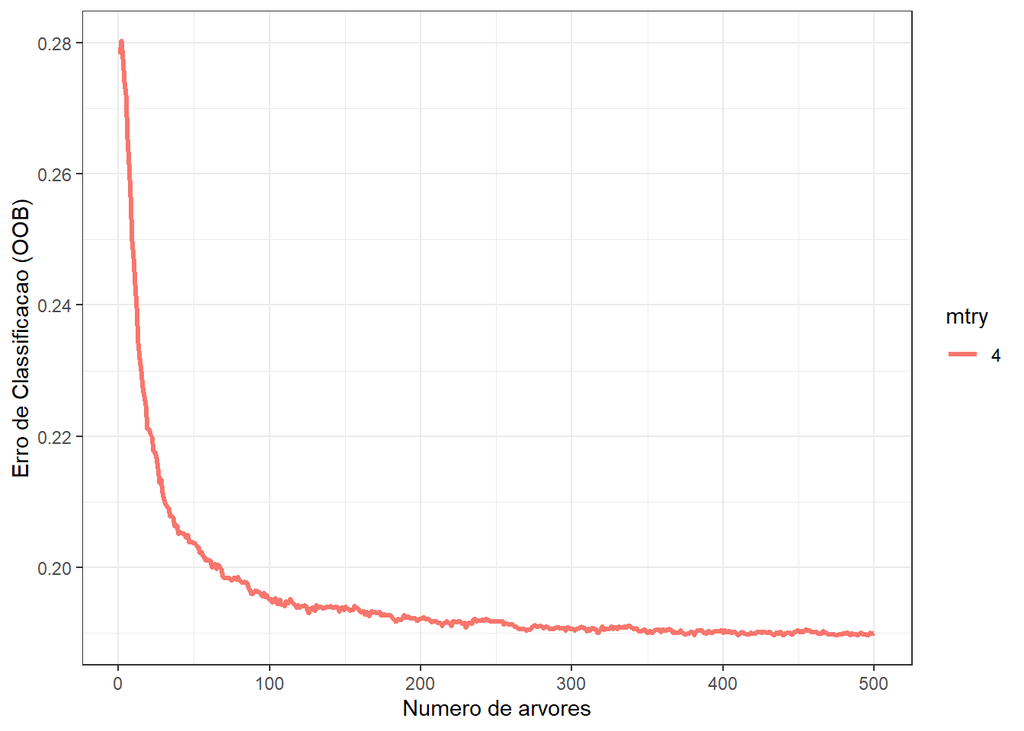

```r
resultados <- tibble(mtry = 4, arvore = 1:nrow(rf$err.rate),oob = rf$err.rate[,1])


resultados %>%
  mutate(mtry = factor(mtry)) %>%
  ggplot(aes(arvore, oob, group = mtry, color = mtry)) +
  geom_line( size = 1.2) +
  ylab("Erro de Classificacao (OOB)") +
  xlab("Numero de arvores") + theme_bw()
```

Atráves do código abaixo, pudemos realizar a visuaçização da importancia das variaveis dentro do modelo de regressão gerado.

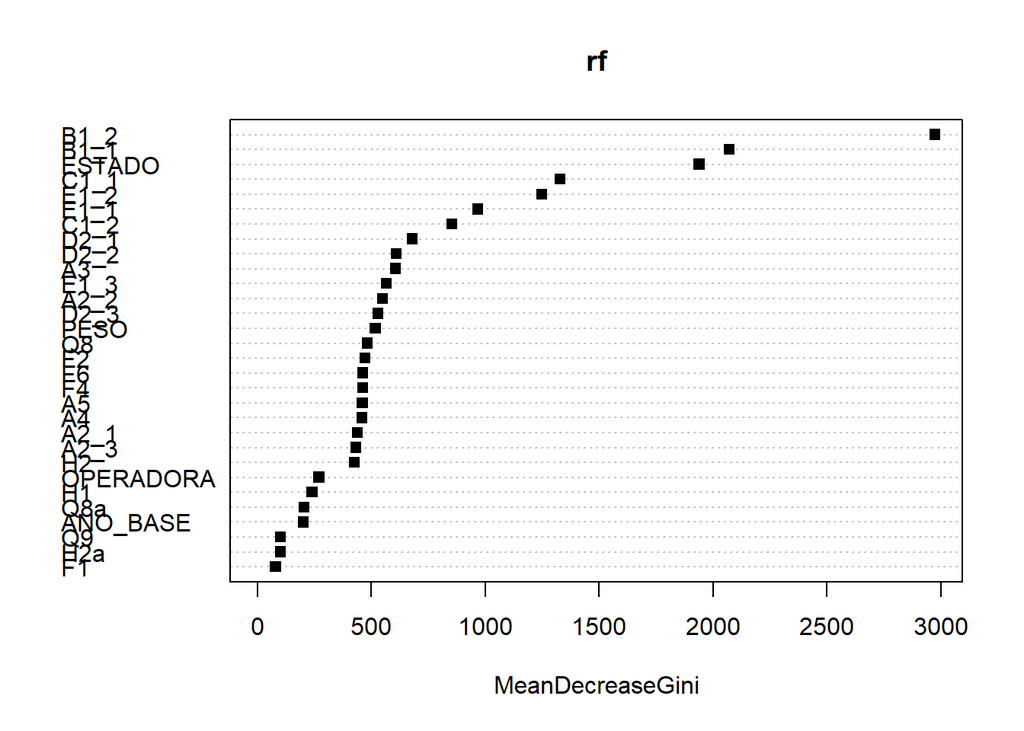

```r
# Importancia de cada variavel
varImpPlot(rf, pch = 15)
```

Matriz de confusão gerada a partir da classficação RF:

```r
rf
```

```
##
## Call:
##  randomForest(formula = J1 ~ ., data = dados_rf[linhas_rf, ])
##                Type of random forest: classification
##                      Number of trees: 500
## No. of variables tried at each split: 6
##
##         OOB estimate of  error rate: 19%
## Confusion matrix:
##       Baixa  Alta class.error
## Baixa 16105  4704   0.2260560
## Alta   3363 18280   0.1553851
```

Agora, vamos realizar o calculo das predições e verificar a curva ROC e a AUC correspondente:

```r
# Criação de conjunto de teste
J1_test <- dados_rf[-linhas_rf,]


predito_rf_prob <- predict(rf, newdata = J1_test, type = "prob")
roc_rf <- roc(J1_test$J1, predito_rf_prob[,1])
# curva roc_rf gerando uma AUC de 0.8936
roc_rf
```

```
##
## Call:
## roc.default(response = J1_test$J1, predictor = predito_rf_prob[,     1])
##
## Data: predito_rf_prob[, 1] in 48249 controls (J1_test$J1 Baixa) > 50808 cases (J1_test$J1 Alta).
## Area under the curve: 0.8936
```

Através do comando `roc_rf`podemos chegar ao resultado de **AUC de 89,36%** para o **modelo RF** rodado.

Abaixo a plotagem da curva ROC para o modelo RF:

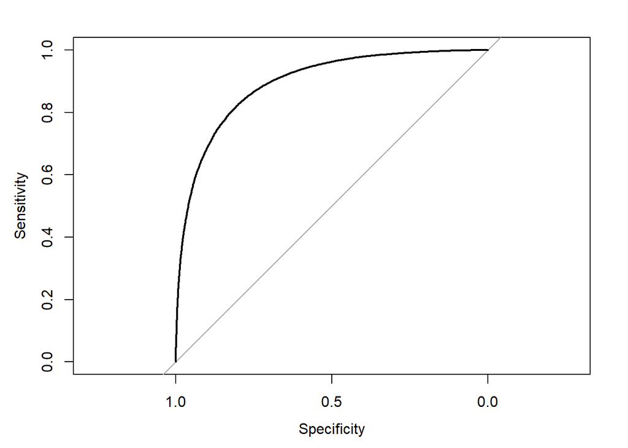

```r
plot(roc_rf)
```

### **3) Boosting**

Assim como na Random Forest, tambémé necessário transformar as variáveis string para factor antes de iniciar o modelo de Boosting:

```r
dados_import_bst <- read_excel("data/BD_Pre_Tratado.xlsx")


### Transformando variaveis chr em fct
dados_import_bst$OPERADORA <- as.factor(dados_import_bst$OPERADORA)
dados_import_bst$ESTADO <- as.factor(dados_import_bst$ESTADO)


### Remover possíveis NAs
dados_bst <- na.omit(dados_import_bst)


### Variavel de J1 (Satisfaçao) transformada e "Alta" ou "Baixa"
dados_bst <- dados_bst %>%
  mutate(J1 = factor(ifelse(J1 >= 8, "Alta", "Baixa"),
                     levels = c("Baixa", "Alta")))
```

Criação de conjuntos de treinamento e teste:

```r
set.seed(1)

linhas <- sample(nrow(dados_bst), .5*nrow(dados_bst))
dados_tr   <- dados_bst[linhas, ]
dados_test <- dados_bst[-linhas,]
```

Transformação da variavel J1 em 0 e 1 (dist. Bernoulli).

Em seguida, criacao da funcao fit para o modelo boosting:

```r
# Transformacao de variavel de satisfacao em 0 ou 1
dados_tr$J1 <- ifelse(dados_tr$J1 == "Alta", 1, 0)
dados_test$J1 <- ifelse(dados_test$J1 == "Alta", 1, 0)


(fit_bst <- gbm(J1 ~ ., distribution = "bernoulli",
                n.trees = 1000, interaction.depth = 4,
                shrinkage = 0.05, data = dados_tr))
```

```
## gbm(formula = J1 ~ ., distribution = "bernoulli", data = dados_tr,
##     n.trees = 1000, interaction.depth = 4, shrinkage = 0.05)
## A gradient boosted model with bernoulli loss function.
## 1000 iterations were performed.
## There were 38 predictors of which 38 had non-zero influence.
```

```r
### Probabilidade de dados teste
prob_bst <- predict(fit_bst, dados_test, n.trees = 1000, type = "response")

### Transforma probabilidade em binário
predito_bst <- ifelse(prob_bst >= .5, 1, 0)
```

Verificando a media entre os valores observados da amostra de teste que diferem dos estimados pelo modelo

```r
mean(dados_test$J1 != predito_bst)
```

```
## [1] 0.1851601
```

### **4) LASSO**

Importando base de dados:

```r
dados_import_LSS <- read_excel("data/BD_Pre_Tratado.xlsx")
```

Classificando a satisfação do cliente entre “Alta” (nota maior/igual a 8) e “Baixa” (nota menor que 8) na variável J1 do questionario:

```r
dados_import_LSS <- dados_import_LSS %>%
  mutate(J1 = factor(ifelse(J1 >= 8, "Alta", "Baixa"),
                     levels = c("Baixa", "Alta")))


# Eliminando possíveis celular sem preenchimento
dados_LSS <- na.omit(dados_import_LSS)
```

Verificando dados importados:

```r
head(dados_import_LSS)
```

| OPERADORA | ESTADO | ANO_BASE | Q5 | Q8 | Q8a | Q9 | J1 | B1_1 | B1_2 | C1_1 | C1_2 | D1 | D2_1 | D2_2 | D2_3 | E1_1 | E1_2 | E1_3 | A1_1 | A1_2 | A1_3 | A1_4 | A2_1 | A2_2 | A2_3 | A3 | A4 | A5 | F1 | … |
| --- | --- | --- | --- | --- | --- | --- | --- | --- | --- | --- | --- | --- | --- | --- | --- | --- | --- | --- | --- | --- | --- | --- | --- | --- | --- | --- | --- | --- | --- | --- |
| OI | RN | 2019 | 1 | 56 | 8 | 1 | Baixa | 10 | 7 | 8 | 10 | 2 | 6.957055 | 6.938650 | 6.865031 | 0 | 0 | 10 | 0 | 0 | 1 | 0 | 7.588235 | 7.647059 | 8.411765 | 8.058824 | 8.588235 | 10.000000 | 1 | … |
| CLARO | RN | 2019 | 1 | 56 | 8 | 1 | Alta | 10 | 10 | 10 | 10 | 1 | 10.000000 | 10.000000 | 10.000000 | 10 | 10 | 10 | 1 | 0 | 1 | 0 | 0.000000 | 10.000000 | 10.000000 | 10.000000 | 8.875000 | 10.000000 | 1 | … |
| TIM | SE | 2019 | 1 | 40 | 6 | 2 | Baixa | 4 | 5 | 7 | 7 | 2 | 7.221519 | 7.310127 | 7.348101 | 7 | 5 | 8 | 0 | 0 | 0 | 1 | 7.375000 | 7.250000 | 7.000000 | 7.500000 | 7.375000 | 7.500000 | 2 | … |
| OI | GO | 2019 | 1 | 23 | 3 | 1 | Alta | 8 | 7 | 10 | 8 | 1 | 9.000000 | 9.000000 | 9.000000 | 9 | 8 | 9 | 0 | 1 | 0 | 0 | 8.000000 | 9.000000 | 9.166667 | 8.833333 | 8.000000 | 7.833333 | 2 | … |
| TIM | TO | 2019 | 1 | 21 | 3 | 1 | Baixa | 7 | 7 | 5 | 6 | 2 | 7.368421 | 7.379501 | 7.739612 | 1 | 3 | 10 | 1 | 0 | 0 | 0 | 8.000000 | 6.000000 | 9.000000 | 6.000000 | 8.157895 | 7.947368 | 1 | … |
| CLARO | MT | 2019 | 1 | 49 | 7 | 2 | Baixa | 10 | 10 | 7 | 7 | 2 | 7.672065 | 7.603239 | 7.566802 | 10 | 10 | 10 | 0 | 0 | 0 | 1 | 7.055556 | 7.277778 | 6.888889 | 7.500000 | 7.944444 | 8.500000 | 2 | … |

Montagem da base para treino e teste:

```r
X <- model.matrix(J1 ~ ., data = dados_LSS[,-1])[,-1]
y <- dados_LSS$J1

set.seed(1)

idx <- sample(nrow(dados_LSS), size = .8*nrow(dados_LSS), replace = FALSE) # indice treinamento
```

Rodando LASSO com o indice de treino:

```r
lasso <- glmnet(X[idx,], y[idx], alpha = 1, nlambda = 1000, family = "binomial")
```

Ajustando o modelo com o lambda otimo:

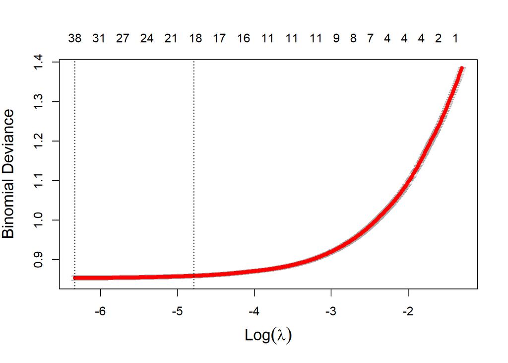

```r
cv_lasso <- cv.glmnet(X[idx,], y[idx], alpha = 1, lambda = lasso$lambda, family = "binomial")
plot(cv_lasso, cex.lab = 1.3)
```

Obtendo as predições para a classificação LASSO:

```r
prob_lasso <- predict(lasso, newx = X[-idx,], s = cv_lasso$lambda.min, type = "response")
```

Criando dataframe com os resultados observados e as estimativas geradas:

```r
estimativa_lasso <- tibble(observado = y[-idx], probabilidade = prob_lasso)
```

Curva ROC e a AUC estimada:

```r
roc_lasso <- estimativa_lasso %>%
  roc(observado, probabilidade)
#Rodando curva ROC, obtendo resultado de AUC = 0,89
roc_lasso
```

```
##
## Call:
## roc.data.frame(data = ., response = observado, predictor = probabilidade)
##
## Data: probabilidade in 13786 controls (observado Baixa) < 14516 cases (observado Alta).
## Area under the curve: 0.8888
```

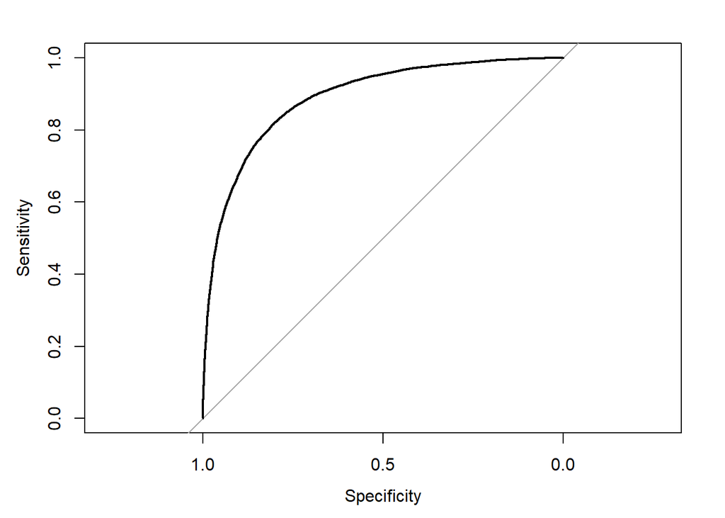

```r
plot(roc_lasso)
```

Podemos observar atraves da AUC obtida pela curva ROC que o % de acertos deste modelo é de **88,88%**.

### **Resumo dos resultados para os modelos testados:**

Observa-se que o **Random Forest** apresentou um melhor desempenho preditivo de classificação para a base de dados de telefonia analisada.